# Regression Diagnostics in R

2026-04-07

## Objectives

- We will see one example of linear regression
- Look at diagnostics plots and tests.
- Remember the four assumptions of a linear model:
1. Linearity
2. Normally distributed errors (most important when you have a small sample size (because CLT isn’t working in your favor), and when you’re interested in constructing confidence intervals/doing significance testing.)
3. Homoscedasticity/homogeneity of variance
4. Independence
- Another important thing to check: No influential outliers! (Not an assumption)

## Read data

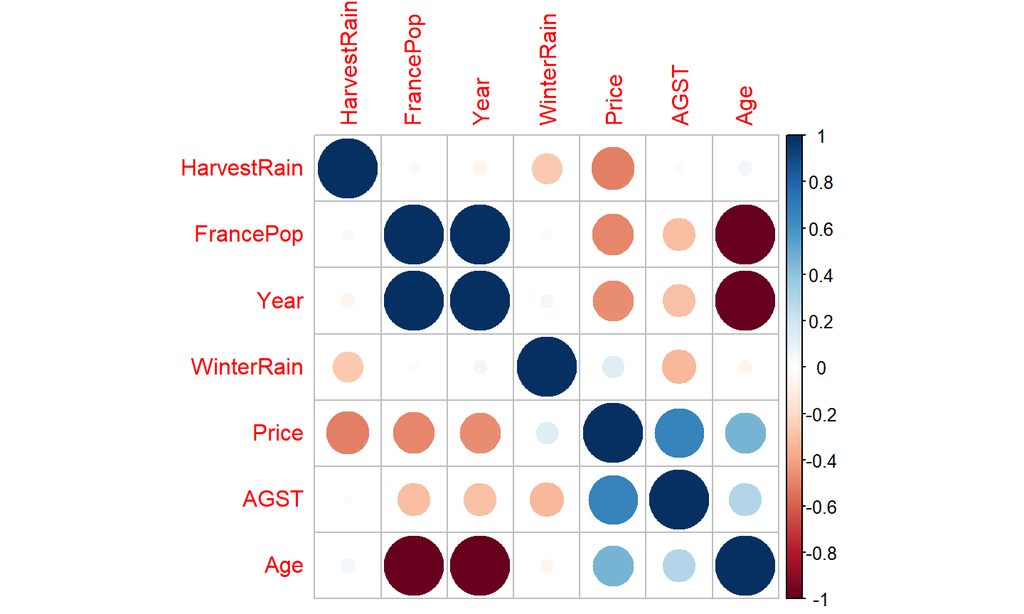

```r
setwd("C:/Users/jyotishka/OneDrive/Documents/Course Notes/CMDA 2006/iqs2-jd/latexppt/regression_intro")
wine <- read.csv("datasets/wine.csv")
library(corrplot)
corrplot(cor(wine), order = 'AOE')
```

## Fit the first linear model

```r
## Include all of the predictors
modWine1 <- lm(Price ~ Age + AGST + FrancePop + HarvestRain + WinterRain, data = wine)
summary(modWine1)
```

```
##
## Call:
## lm(formula = Price ~ Age + AGST + FrancePop + HarvestRain + WinterRain,
##     data = wine)
##
## Residuals:
##      Min       1Q   Median       3Q      Max
## -0.46541 -0.24133  0.00413  0.18974  0.52495
##
## Coefficients:
##               Estimate Std. Error t value Pr(>|t|)
## (Intercept) -2.343e+00  7.697e+00  -0.304  0.76384
## Age          1.377e-02  5.821e-02   0.237  0.81531
## AGST         6.144e-01  9.799e-02   6.270 3.22e-06 ***
## FrancePop   -2.213e-05  1.268e-04  -0.175  0.86313
## HarvestRain -3.837e-03  8.366e-04  -4.587  0.00016 ***
## WinterRain   1.153e-03  4.991e-04   2.311  0.03109 *
## ---
## Signif. codes:  0 '***' 0.001 '**' 0.01 '*' 0.05 '.' 0.1 ' ' 1
##
## Residual standard error: 0.293 on 21 degrees of freedom
## Multiple R-squared:  0.8278, Adjusted R-squared:  0.7868
## F-statistic: 20.19 on 5 and 21 DF,  p-value: 2.232e-07
```

## Remove the non-significant variables

- This is not the ideal way of performing model selection but we could remove the non-significant variables and run the regression again.

```r
## Remove the least significant variable
modWine2 <- lm(Price ~ Age + AGST + HarvestRain + WinterRain, data = wine)
summary(modWine2)
```

```
##
## Call:
## lm(formula = Price ~ Age + AGST + HarvestRain + WinterRain, data = wine)
##
## Residuals:
##      Min       1Q   Median       3Q      Max
## -0.46024 -0.23862  0.01347  0.18601  0.53443
##
## Coefficients:
##               Estimate Std. Error t value Pr(>|t|)
## (Intercept) -3.6515703  1.6880876  -2.163  0.04167 *
## Age          0.0238480  0.0071667   3.328  0.00305 **
## AGST         0.6163916  0.0951747   6.476 1.63e-06 ***
## HarvestRain -0.0038606  0.0008075  -4.781 8.97e-05 ***
## WinterRain   0.0011667  0.0004820   2.420  0.02421 *
## ---
## Signif. codes:  0 '***' 0.001 '**' 0.01 '*' 0.05 '.' 0.1 ' ' 1
##
## Residual standard error: 0.2865 on 22 degrees of freedom
## Multiple R-squared:  0.8275, Adjusted R-squared:  0.7962
## F-statistic: 26.39 on 4 and 22 DF,  p-value: 4.057e-08
```

## Manually calculate \(\hat{\beta}\)

- Once again, recall: \(\hat{\boldsymbol{\beta}} = (X^T X)^{-1} X^T y\)

```r
library(dplyr)  ## dplyr is strictly speaking, not necessary here
X <- wine %>% select(c(Age, AGST, HarvestRain, WinterRain)) %>% as.matrix()
X <- cbind(1, X)  ## add a column of 1 for intercepts
y <- wine %>% select(Price) %>% as.matrix()
bHat2 <- solve(crossprod(X), crossprod(X, y))
```

- Compare the manually calculated with the output from `lm`.

```r
t(bHat2)
```

```
##                       Age      AGST HarvestRain  WinterRain
## Price -3.65157 0.02384801 0.6163916  -0.0038606 0.001166719
```

```r
modWine2$coefficients
```

```
##  (Intercept)          Age         AGST  HarvestRain   WinterRain
## -3.651570330  0.023848014  0.616391558 -0.003860600  0.001166719
```

## Diagnostics

- The `lm` function has an in-built model diagnostic tool.
- Using `lm`, regression diagnostics plots (residual diagnostics plots) can be created using the base R function `plot()`.
- Open `R`, run all the previous lines of codes so that you have an `lm` object called `modWine2`.
- Then simply call `plot()` on `modWine2`.

```r
plot(modWine2)
```

- Output plot will be interactive.

## Diagnostics

- **Residuals vs Fitted:** used to check the assumptions of linearity. If the residuals are spread equally around a horizontal line without distinct patterns (red line is approximately horizontal at zero), that is a good indication of having a linear relationship.

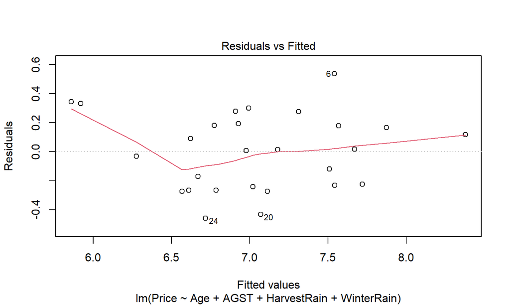

```r
plot(modWine2, 1)
```

## Diagnostics

- **Normal Q-Q:** used to check the normality of residuals assumption. If the majority of the residuals follow the straight dashed line, then the assumption is fulfilled.

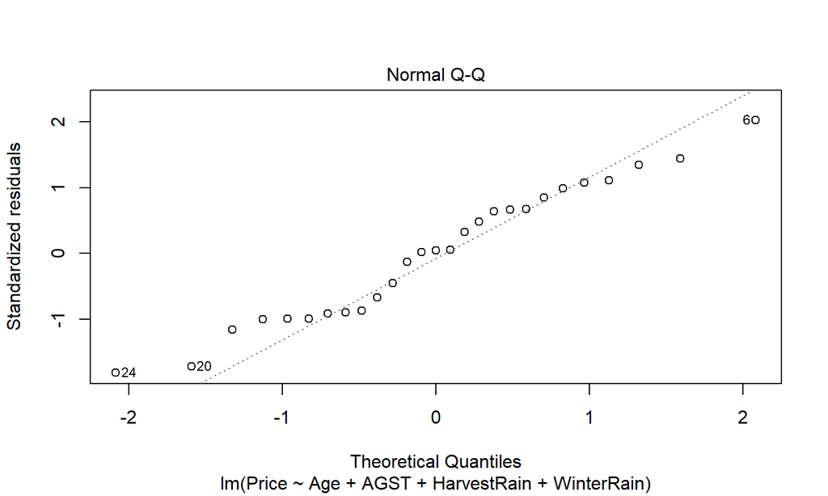

```r
plot(modWine2, 2)
```

## Normality of residuals

- We could also create a histogram to check if the distribution looks like a typical bell-shaped curve.

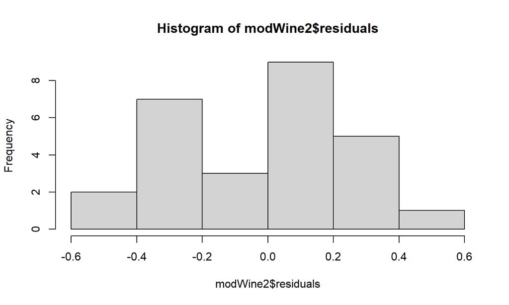

```r
hist(modWine2$residuals)
```

## Normality of residuals

- The QQ-plot or histogram are visual checks — very good for detecting bad deviations, but it helps to do a formal test.
- Using pre-installed `library(MASS)`, get distribution of studentized residuals (i.e. transform residuals for test).

```r
library(MASS)
sresid <- MASS::studres(modWine2)  ## using MASS package function to transform data easily
shapiro.test(sresid)               ## p-value non-significant: normal distribution of residuals
```

```
##
##  Shapiro-Wilk normality test
##
## data:  sresid
## W = 0.97081, p-value = 0.6232
```

## Homoscedasticity

- **Scale-Location:** used to check the homoscedasticity of residuals (equal variance of residuals). If the residuals are spread randomly and we see a horizontal line with equally (randomly) spread points, then the assumption is fulfilled.

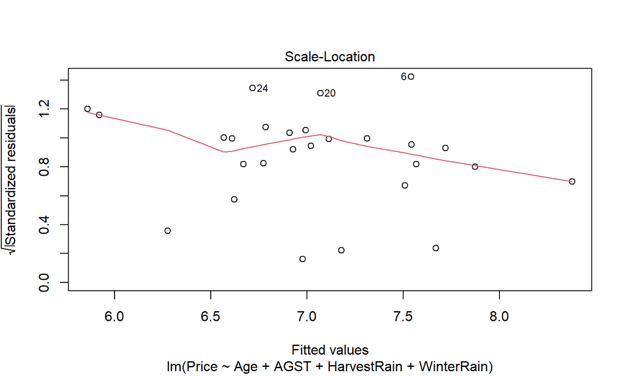

```r
plot(modWine2, 3)
```

## Homoscedasticity violation

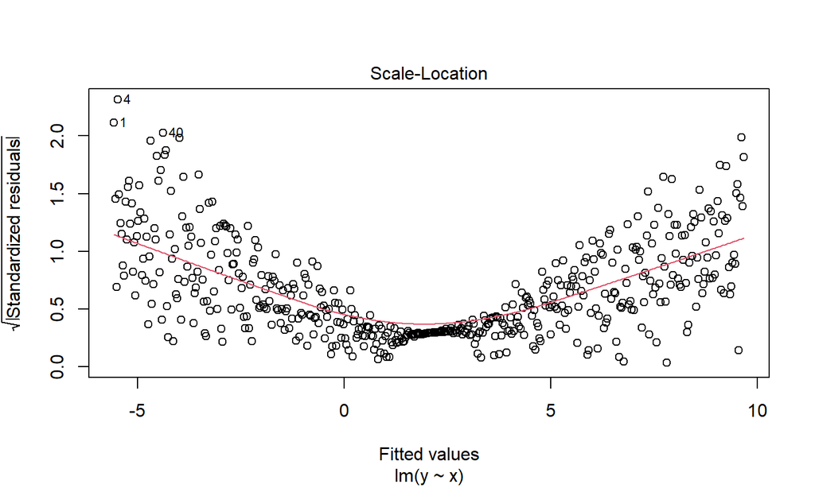

```r
x   <- seq(-2.5, 2.5, length.out = 500)
eps <- rnorm(n = length(x), sd = 0.25 * x^2)
y   <- 2 + 3 * x + eps
lm.bad <- lm(y ~ x)
plot(lm.bad, 3)
```

## Homoscedasticity — formal test

- As with normality, the Scale-Location plot is a visual check. The **Breusch-Pagan test** (via `car::ncvTest`) provides a formal companion.
- \(H_0\): constant error variance (homoscedasticity).

```r
library(car)
ncvTest(modWine2)
```

```
## Non-constant Variance Score Test
## Variance formula: ~ fitted.values
## Chisquare = 0.3254683, Df = 1, p = 0.56834
```

- A large p-value means we fail to reject \(H_0\) — no evidence of heteroscedasticity. A small p-value warrants a closer look at the Scale-Location plot and possible remedies (WLS, variance-stabilising transformation).

## Multicollinearity

- With multiple predictors we should also check that they are not nearly linearly dependent. High multicollinearity inflates standard errors and destabilises coefficient estimates.
- The **Variance Inflation Factor (VIF)** measures how much the variance of \(\hat\beta_j\) is inflated relative to an orthogonal design. A rule of thumb: \(\text{VIF} > 5\) warrants attention; \(> 10\) is serious.

```r
vif(modWine2)  ## car package already loaded above
```

```
##         Age        AGST HarvestRain  WinterRain
##    1.106336    1.246781    1.102734    1.225447
```

- All VIFs close to 1 indicate no problematic collinearity among `Age`, `AGST`, `HarvestRain`, and `WinterRain`.

## Leverage and Influential points

- **Residuals vs Leverage:** used to identify any influential value in our dataset. Influential values are extreme values that might influence the regression results when included or excluded from the analysis.
- *Look for cases outside of a dashed line.*

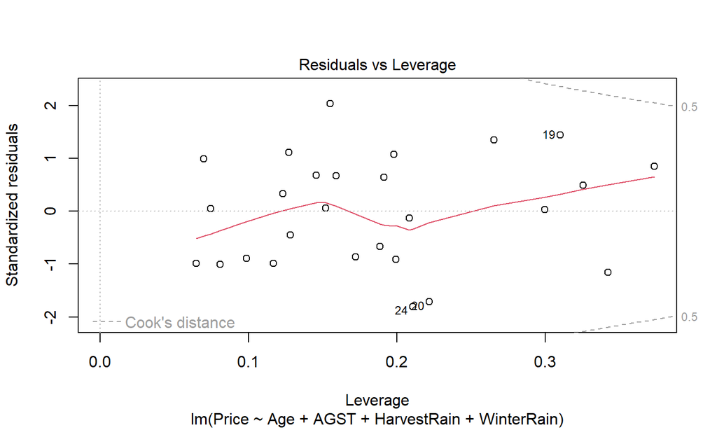

```r
plot(modWine2, 5)
```

## Ideal setting

- The plot below is a great example of a Residuals vs Leverage plot in which we see no evidence of outliers. Those “Cook’s distance” dashed curves don’t even appear on the plot. None of the points come close to having both high residual and leverage.

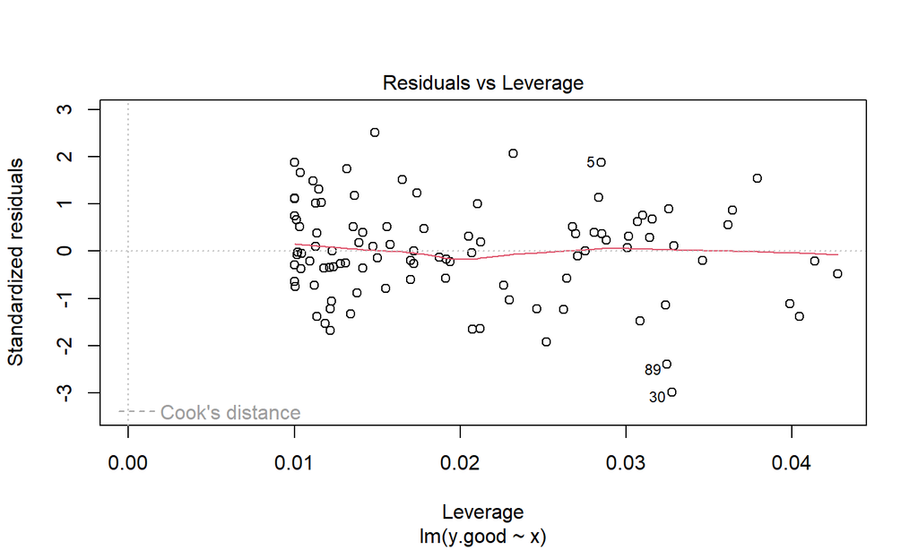

```r
n <- 100
x <- runif(n, min = 0, max = 100)
y.good <- 3 + 0.1 * x + rnorm(n, sd = 3)
lm.good <- lm(y.good ~ x)
plot(lm.good, 5)
```

## Situation with outliers

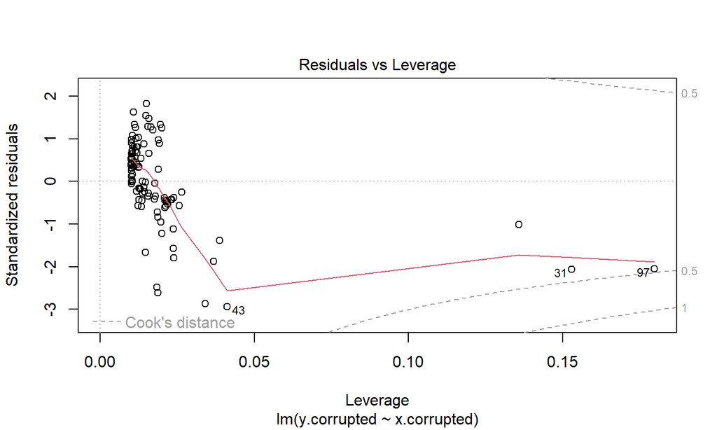

```r
set.seed(123)
y.corrupted <- y.good[1:100]
x.corrupted <- x[1:100]
## Randomly select 10 points to corrupt
to.corrupt <- sample(1:length(x.corrupted), 10)
y.corrupted[to.corrupt] <- -1.5 * y.corrupted[to.corrupt] + rt(10, df = 3)
x.corrupted[to.corrupt] <- x.corrupted[to.corrupt] * 2.5
## Fit regression and display diagnostic plot
lm.corrupted <- lm(y.corrupted ~ x.corrupted)
plot(lm.corrupted, 5)
```

## Auto-correlation

- Finally, we also assume that the errors are not serially correlated, i.e. \(\epsilon_i\) and \(\epsilon_{i+1}\) should not be dependent, like, for example in stock returns.
- Consider \(y_t =\) average daily temperature at O’Hare airport, Jan–Feb 1997. “Sticky” appearance.

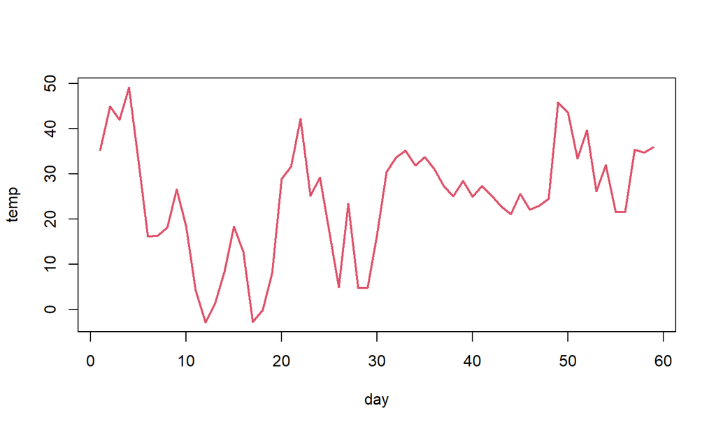

```r
weather <- read.csv("datasets/weather.csv")
plot(weather$temp, xlab = "day", ylab = "temp", type = "l", col = 2, lwd = 2)
```

## Auto-correlation

- To summarize the time-varying dependence, compute lag-\(\ell\) correlations for \(\ell = 1, 2, 3, \dots\)
- The **autocorrelation function (ACF)** for \(y\) is \[ r(\ell) = \mathbb{C}\mathrm{orr}(Y_t, Y_{t-\ell}) \equiv r_{y_t, y_{t-\ell}}. \]
- Blue lines mark “statistical significance”.

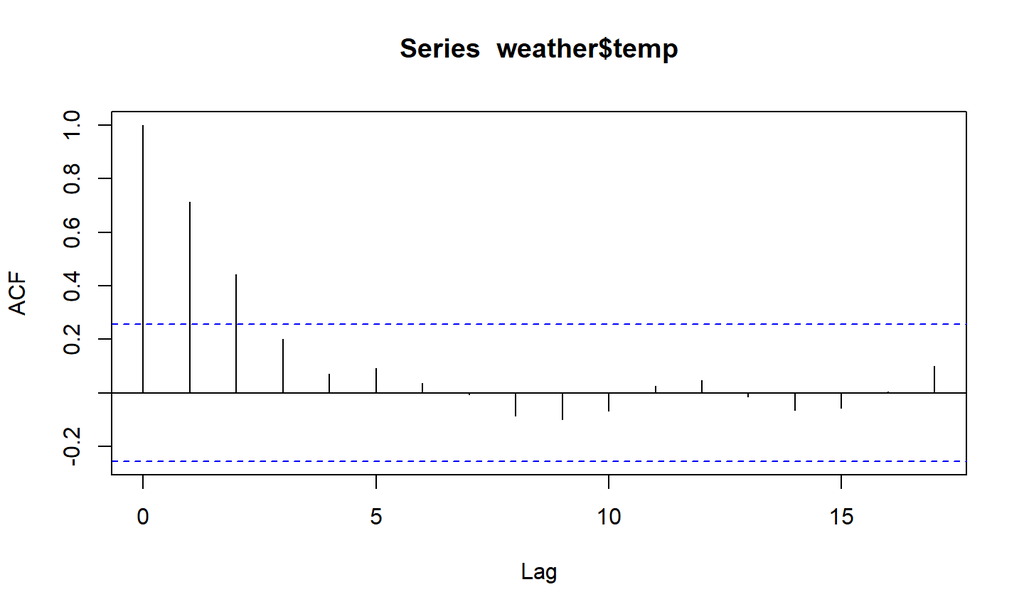

```r
acf(weather$temp)
```

## ACF for linear model

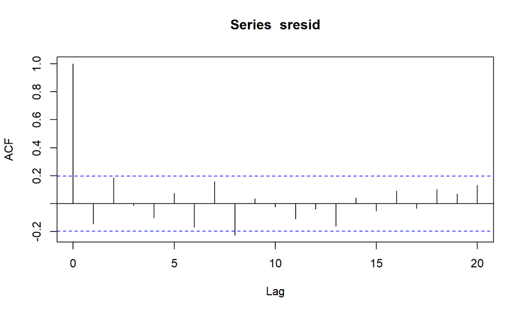

```r
sresid <- MASS::studres(lm.good)
acf(sresid)
```

## ACF for Wine example

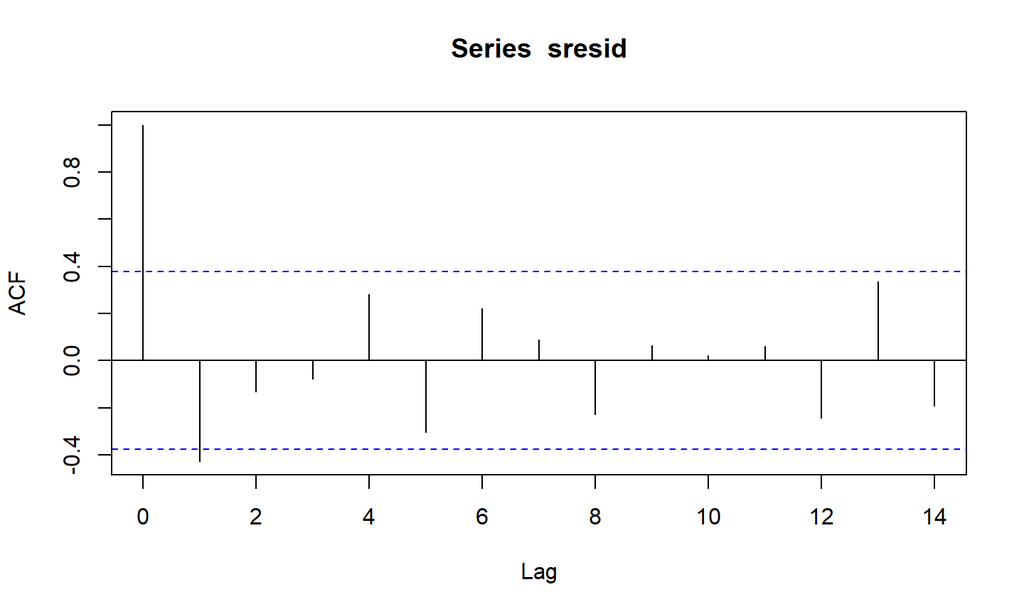

```r
sresid <- MASS::studres(modWine2)
acf(sresid)
```